# Difficulty of Trails at Macleish Station

SDS 192: MP4

Emily Rhyu

Smith College

Alicia Chen

Smith College

Elda Cervantes

Smith College

June 30, 2022

## Prompt

MacLeish has approximately four miles of built trail for use by field station visitors. We would like to be able to classify these trails as “Easy,” “Moderate,” or “Difficult” based on their length and change in elevation. Use the spatial data to develop a heuristic that will classify these (or any other) trails based on their difficulty. You might want to consult existing trail rating systems. It would be cool if you could create elevation profiles (e.g., this one). Be sure to consult the extended example in MDSR, which walks you through creating an elevation map for one trail. This map has some noted weaknesses. Your goal should be to improve on it and/or make similar maps for all trails.

Supporting data includes: - Existing trails layer (trails) - 30’ contour elevation data (elevation) - 3 meter contours can be retrieved from MassGIS (see help(“mass_gis”)) - Property boundary shapefile (boundary)

## How We Did It

Our group chose Prompt 1, which asked us to classify the trails of MacLeish into levels of difficulty using their length and change in elevation. We began by exploring the MacLeish package in R Studio and familiarized ourselves with the dataset, “macleish_layers.” Our next step was figuring out the length of each trail and calculating each one’s elevation. We ran into some problems while creating a function to graph the elevation of all the trails. We first tested out the function with the longest trail in the dataset, and then tested it with other, randomly selected trails. This seemed to work, but we ran into another issue after doing this. Although our function worked when we passed separate trails in as arguments, it didn’t work when we tried to use the map() function to do the same with the entire “trails_full” dataset. We then attempted to split the dataset into separate rows and use a for loop to call our function for each trail, but this gave us more errors (albeit different ones). Ultimately, we decided to graph every trail at once and facet wrap it by name to produce the elevation maps of all the trails. We encountered an issue where some of the trails’ graphs were cut off, but were able to fix it after some help from our peers in the questions channel in the class Slack.

The ratings for the trails weren’t very distinctive initially. All the trail levels were “Easy” according to the Shenandoah rating system as the area of MacLeish is pretty much flat and even the longest trail is only about 1.6 miles. Therefore, we created our own rating system in order to accommodate for the smaller scale: ratings 0-5 are ranked easy, ratings 5-10 are ranked moderate, and ratings 10-20 are ranked difficult.

## Loading the data

```r
library(macleish)
```

```r
trails <- macleish_layers %>%
  pluck("trails")

contour <- mass_gis("contours250k")
boundary <- macleish_layers %>%
  pluck("boundary")

elevations <- macleish_layers %>%
  pluck("elevation")
```

## Finding the Lengths and Elevations of all the Trails

```r
#find the lengths of all the trails by segments
trails_full <- trails %>%
  group_by(name) %>%
  summarize(num_segments = n()) %>%
  mutate(trail_length = st_length(geometry)) %>%
  arrange(desc(trail_length))

#finds elevation for all the trails by segments
trail_elevations <- trails_full %>%
  st_intersection(elevations) %>%
  st_cast("MULTIPOINT") %>%
  st_cast("POINT")
trail_elevations
```

| name | num_segments | trail_length | OBJECTID | Shape_Leng | Shape_Area | CONTOUR_FT | INDEX_ARC | SHAPE_LEN | geometry |
| --- | --- | --- | --- | --- | --- | --- | --- | --- | --- |
| Snowmobile Trail | 2 | 2576.0933 [m] | 1 | 5893.578 | 1033988 | 870 | N | 640.7643 |  |
| Snowmobile Trail | 2 | 2576.0933 [m] | 1 | 5893.578 | 1033988 | 870 | N | 640.7643 |  |
| Poplar Hill Road | 2 | 1040.4175 [m] | 1 | 5893.578 | 1033988 | 870 | N | 640.7643 |  |
| Poplar Hill Road | 2 | 1040.4175 [m] | 1 | 5893.578 | 1033988 | 870 | N | 640.7643 |  |
| Snowmobile Trail | 2 | 2576.0933 [m] | 1 | 5893.578 | 1033988 | 810 | N | 4913.9158 |  |
| Eastern Loop | 2 | 1939.2452 [m] | 1 | 5893.578 | 1033988 | 810 | N | 4913.9158 |  |
| Eastern Loop | 2 | 1939.2452 [m] | 1 | 5893.578 | 1033988 | 810 | N | 4913.9158 |  |
| Eastern Loop | 2 | 1939.2452 [m] | 1 | 5893.578 | 1033988 | 810 | N | 4913.9158 |  |
| Eastern Loop | 2 | 1939.2452 [m] | 1 | 5893.578 | 1033988 | 810 | N | 4913.9158 |  |
| Western Loop | 3 | 1350.0538 [m] | 1 | 5893.578 | 1033988 | 810 | N | 4913.9158 |  |

[output cut: 33 more lines]

[output not shown]

## Elevation Maps

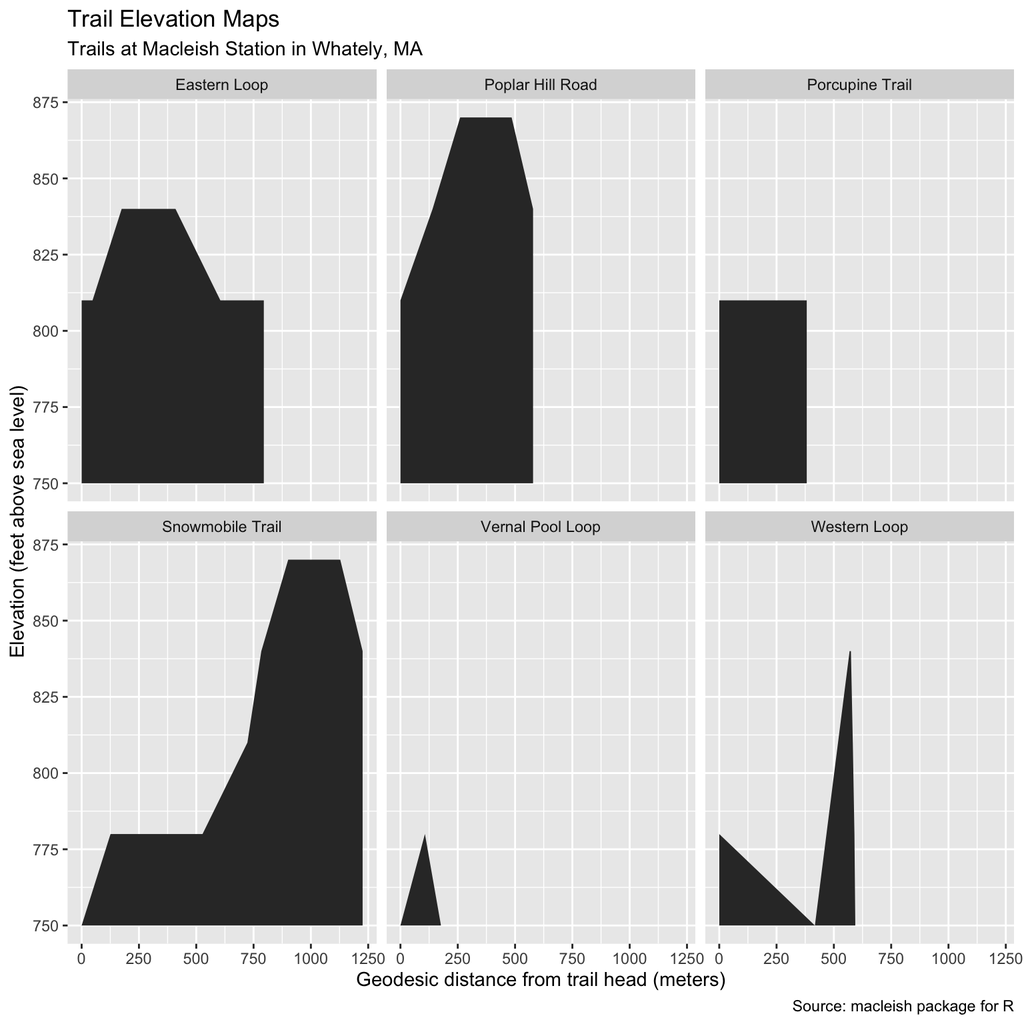

```r
elevationGrapher <- function(trail_elevations) {
  trail_elevations <- trail_elevations %>%
    group_by(name) %>%
    mutate(lat = st_coordinates(geometry)[, 2]) %>%
    arrange(lat) %>%
    mutate(distance_from_start = as.numeric(st_distance(geometry)[, 1]))


  ggplot(trail_elevations, aes(x = distance_from_start)) +
    geom_ribbon(aes(ymax = CONTOUR_FT, ymin = 750)) +
    scale_y_continuous("Elevation (feet above sea level)") +
    scale_x_continuous("Geodesic distance from trail head (meters)") +
    labs(title = "Trail Elevation Maps",
         subtitle = "Trails at Macleish Station in Whately, MA",
         caption = "Source: macleish package for R") +
    facet_wrap( ~ name)
}

elevationGrapher(trail_elevations)
```

## The Trail Ratings using Shenandoah system

```r
trail_ratings <- trail_elevations %>%
  group_by(name) %>%
  summarize(
    gain = max(CONTOUR_FT) - min(CONTOUR_FT),
    trail_length = max(units::set_units(trail_length, "miles")),
    rating = sqrt(gain * 2 * as.numeric(trail_length))
  )

trail_ratings <- trail_ratings %>%
  mutate(difficulty = case_when(
    between(rating, 0, 5) ~ "Easy",
    between(rating, 5, 10) ~ "Moderate",
    between(rating, 10, 20) ~ "Difficult",
  ))
```

## Static maps

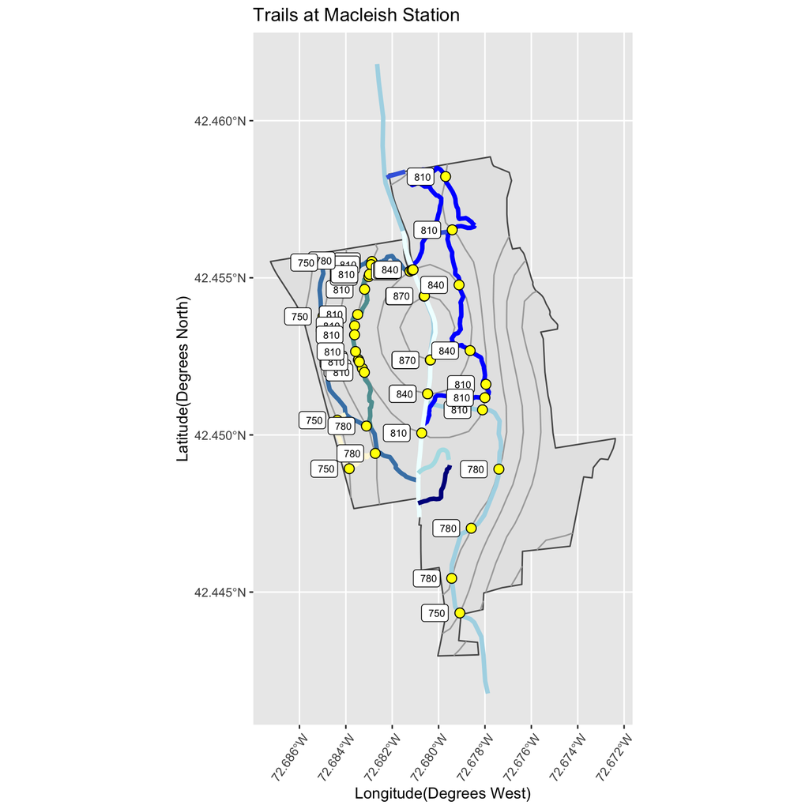

```r
boundary_plot <- ggplot() +
  geom_sf(data = boundary)

bluePalette <-
  c(
    "lightblue",
    "blue",
    "steelblue",
    "azure",
    "cadetblue",
    "cornsilk",
    "darkblue",
    "powderblue",
    "royalblue"
  )

boundary_plot +
  geom_sf(data = elevations, color = "dark gray") +
  geom_sf(data = trails_full[1,],
          color = "lightblue",
          size = 1.5) +
  geom_sf(data = trails_full[2,],
          color = "blue",
          size = 1.5) +
  geom_sf(data = trails_full[3,],
          color = "steelblue",
          size = 1.5) +
  geom_sf(data = trails_full[4,],
          color = "azure",
          size = 1.5) +
  geom_sf(data = trails_full[5,],
          color = "cadetblue",
          size = 1.5) +
  geom_sf(data = trails_full[6,],
          color = "cornsilk",
          size = 1.5) +
  geom_sf(data = trails_full[7,],
          color = "darkblue",
          size = 1.5) +
  geom_sf(data = trails_full[8,],
          color = "powderblue",
          size = 1.5) +
  geom_sf(data = trails_full[9,],
          color = "royalblue",
          size = 1.5) +
  geom_sf(
    data = trail_elevations,
    fill = "yellow",
    pch = 21,
    size = 3
  ) +
  geom_sf_label(
    data = trail_elevations,
    aes(label = CONTOUR_FT),
    hjust = "right",
    size = 2.5,
    nudge_x = -0.0005
  ) +
  theme(axis.text.x = element_text (
    angle = 55,
    vjust = .89,
    hjust = .9
  )) +
  scale_colour_manual(
    name = "Trails",
    values = c(
      "Snowmobile Trail" = "lightblue",
      "Eastern Loop" = "blue",
      "Western Loop" = "steelblue"
    )
  ) +
  xlab("Longitude(Degrees West)") +
  ylab("Latitude(Degrees North)") +
  labs(title = "Trails at Macleish Station")
```

## Dynamic maps

```r
library(leaflet)

pal <-
  colorFactor(
    palette = c("green", "blue", "red"),
    levels = c("Easy", "Moderate", "Difficult")
  )

leaflet() %>%
  addTiles() %>%
  addPolygons(data = boundary, weight = 3) %>%
  addPolylines(
    data = trails,
    weight = 2,
    color = ~ pal(trail_ratings$difficulty),
    label = trails$name
  ) %>%
  addPolygons(data = elevations,
              weight = 1,
              color = "yellow") %>%
  addLegend(
    title = "Trail Difficulty",
    position = "bottomright",
    pal = pal,
    values = c("Easy", "Moderate", "Difficult"),
    opacity = 1
  )
```

[interactive chart not shown]

## Word count

| Method | koRpus | stringi |
| --- | --- | --- |
| Word count | 769 | 776 |
| Character count | 4680 | 4867 |
| Sentence count | 61 | Not available |
| Reading time | 3.8 minutes | 3.9 minutes |

## Standards

In this assignment, we attempted the following [standards](https://beanumber.github.io/sds192/standards.html):

- : We mastered the Wrangling standard since we used tools like group_by(), summarize(), and mutate() in order to manipulate our data for our purposes. We thereby optimized readability and performance.
- : We met the Spatial standard since we used shapefiles in conjunction with ggplot2 to create spatial plots.
- : We met the Leaflet standard since we created a leaflet map of the MacLeish area with geospatial layers.
- : We mastered the aesthetics standard as the data graphics are customized and make use of different geoms and colors.
- : We mastered the R Markdown standard since the code we’ve written compiles properly, and we haven’t included things that would slow down the code unnecessarily, like the loading statements.
- : We mastered the Github standard as we used Github to effectively work together.
- : We mastered the Context standard as all of our data graphics are clearly labeled and tell a story.
- : We mastered the Iteration standard since we applied a function, elevationGrapher, to multiple rows and variables.
- : We mastered the Function standard since we wrote a user-defined function, elevationGrapher, that takes in the data on all the trails and then gives an elevation map for each one.

## References

- Benjamin S. Baumer, Rose Goueth, Wencong Li, Weijia Zhang and Nicholas Horton (NA). macleish: Retrieve Data from MacLeish Field Station. R package version 0.3.6. http://github.com/beanumber/macleish
- Baumer, Benjamin, et al. Modern Data Science with R. CRC Press, 2021.
- Majerus, Rich, et al. “Creating a Color Palette Using ColorFactor.” R, Datacamp, campus.datacamp.com/courses/interactive-maps-with-leaflet-in-r/plotting-points?ex=15.
- Margalit, Sivan. “Sort Values Into Groups by Ranges.” RStudio Community, 11 Apr. 2020, community.rstudio.com/t/sort-values-into-groups-by-ranges/60881.
- Ogle, Derek H. “Collapsing Categories or Values.” Derek Ogle, 30 Mar. 2018, derekogle.com/fishR/2018-03-30-Collapsing_Values.